# R script for the paper by Pilotto, Rojas & Buckland: Late Holocene anthropogenic landscape change in north-western Europe impacted insect biodiversity as much as climate change did after the last Ice Age

F. Pilotto

11th April, 2022

This document reports the steps to reproduce the results and figures in the manuscript, after the network analysis.

First, we load the R packages. The versions of the used packages and of R are reported at the end of the document.

```r
library(biogeonetworks)
library(ggplot2)
library(dplyr)
library(scales)
library(gridExtra)
library(rworldmap)
library(cowplot)
library(tidypaleo)
library(reshape)
library(indicspecies)
library(tidyr)
library(stringr)
```

# 1. Figure 1

This section produces Figure 1, showing the spatial and temporal distribution of the samples. First we read the network output (in this case the taxonomic network, but it would be the same with the trait network), and we add the info about the age and coordinates of the samples, from the table *LegendSamples*.

```r
Taxonomy_network <-readInfomapTree("Files/Network_taxonomy_states.tree", network.summary = T, replace.leaf.names = F)
LegendSamples <- read.table("Files/LegendSamples.csv",h=T, sep=",", quote="\"", fill=FALSE)
names(LegendSamples)[1] <- "sample_identifier_short"
Samples_nw <- merge(LegendSamples, Taxonomy_network, by.x="sample_identifier_short",  by.y="Name")
Samples_nw <- Samples_nw
```

For panel 1A, showing the geographic distribution of the samples, we first obtain the background world map using *getMap()*, and then we create the plot.

```r
world2 <- fortify(spTransform(getMap(),
                              CRS("+proj=longlat +datum=WGS84 +no_defs +ellps=WGS84 +towgs84=0,0,0")))


# plot:
Fig1A <- ggplot()+
  geom_map(data=world2, map=world2,
           aes(x=long, y=lat, map_id=id),
           fill="grey83", size=0.25)+
  coord_equal()+
  xlim(c(-12, 23))+ ylim(c(43, 68))+
  theme_bw()+
  geom_point(data = Samples_nw,
    aes(longitude_dd, latitude_dd, col=(-1*Age_BP_From)),
    size=2, alpha=1, shape=21) +
    labs(colour = "Age (yrs BP)") +
  ylab("Latitude (\u00B0)")+
  xlab("Longitude (\u00B0)")+
  scale_colour_continuous(guide="none")+
  theme( axis.text=element_text(size=7),
         legend.title = element_text( size=7), legend.text=element_text(size=7),
         legend.position ="NULL")
```

For panel 1B, showing the temporal distribution of the samples, we order the samples by *Age_BP_To* and create the plot.

```r
# order samples by Age_BP_To
Samples_nw <- Samples_nw[order(Samples_nw$Age_BP_To),]

# plot:
Fig1B <- ggplot() +
  geom_segment(data=Samples_nw,
               mapping=aes(x=Age_BP_From, y=c(1:length(Samples_nw$Age_BP_To)),
                           xend=Age_BP_To, yend=c(1:length(Samples_nw$Age_BP_To)),
                           col=(-1*Age_BP_From)), size=0.5)+
  scale_x_reverse(labels = scales::comma, minor_breaks=seq(0,16000, by=1000))+
  theme_bw()+
  ylab("Sample")+
  xlab("Age (yrs BP)")+
  theme(axis.text=element_text(size=7), legend.title = element_text( size=7),
        legend.text=element_text(size=7), legend.position = "none")+
  labs(colour = "Age (yrs BP)")
```

The combined figure is the following.

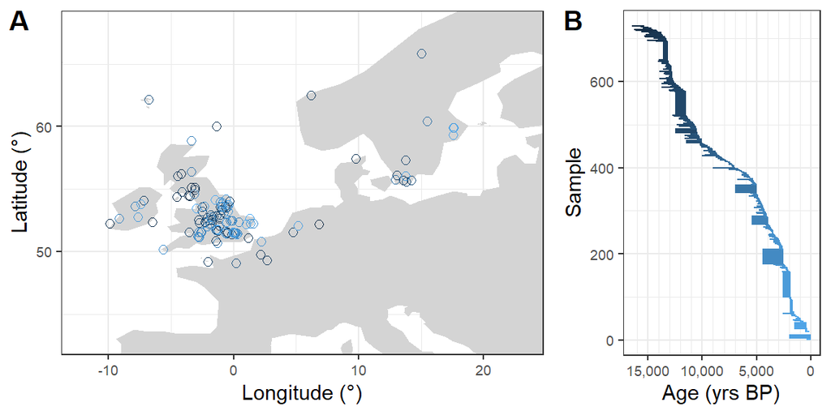

```r
#tiff("Figure1.tif",6,3,units="in",compression="lzw",res=600)
plot_grid(Fig1A, Fig1B,
          labels = c("A", "B"),align = "h", axis = "bt", rel_widths = c(3,1.5))
```

```r
#dev.off()
```

FIGURE 1. Geographical and temporal scope of the study: location of the 729 samples at 145 sites (A), the colour of the dots reflects the age ranges of the samples (B).

# 2. Figure 2

Figure 2A shows the results of the network analysis based on the taxonomy and ecological traits. The values used for the plot come from the results of the network analysis (see Supplementary Figure S3).

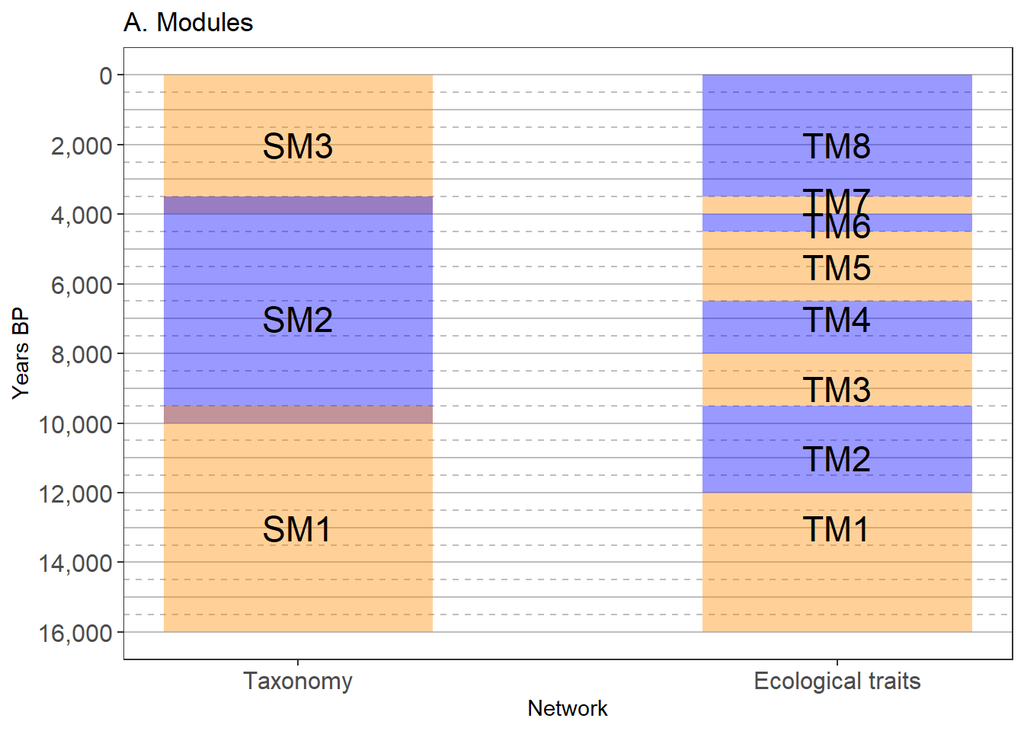

```r
Modules <- read.table("Files/Modules.csv",h=T, sep=",", quote="\"", fill=FALSE)
names(Modules)[1]<- "Module" #rename first column
Modules_traits <- Modules[Modules$Network=="Trait",]
Modules_taxa <- Modules[Modules$Network=="Taxa",]

Fig2A <- ggplot()+
  scale_x_reverse(breaks=seq(0,16000,  2000),labels =comma)+
  theme_bw()+
  theme(panel.background = element_blank(),
        panel.grid.major.x = element_blank(), panel.grid.minor.x = element_blank())+
  geom_vline(xintercept=seq( 0, 16000,by=500),colour="grey", linetype="dashed")+
  geom_vline(xintercept=seq( 0, 16000,by=1000),colour="grey")+
  ylab("Network")+
  xlab("Years BP")+
  ggtitle("A. Modules")+
  annotate("rect", xmin = Modules_taxa$Yr_from, xmax = Modules_taxa$Yr_to, ymin = 1, ymax = 3,
           fill=c("darkorange", "blue", "darkorange"), alpha = .4) +
  # traits
  annotate("rect", xmin = Modules_traits$Yr_from, xmax = Modules_traits$Yr_to, ymin = 5, ymax = 7,
         fill=c( "blue", "darkorange", "blue","darkorange", "blue","darkorange", "blue","darkorange"),
           alpha = .4)  +
  scale_y_continuous(breaks=c(2,6), labels = c("Taxonomy", "Ecological traits")) +
  annotate("text", x=c(2000,7000,13000 ), y=c(2), label=Modules_taxa$Name, size=6)+
  annotate("text", x=c(2000,3600,4300,5500,7000,9000,11000,13000 ), y=6, label=Modules_traits$Name, size=6)+
  theme( axis.text=element_text(size=12))+
  coord_flip()
```

FIGURE 2A: Results of the network analysis based on the taxonomy (modules SM1-3) and ecological traits (modules TM1-8).

Figure 2B shows the relative temperature changes based on oxygen isotope data from Greenland ice cores, as an independent proxy of temperature.

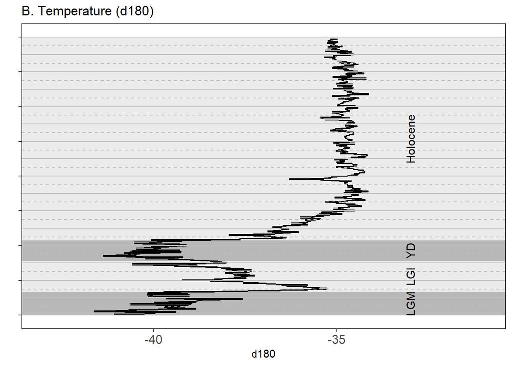

```r
Ox <- read.table("Files/D18O GISP2 for SEAD use Age BP (SEAD).csv",h=T, sep=",", quote="\"", fill=FALSE)
names(Ox) <- c("years.b2k", "d18O", "AgeBP")
Ox16000 <- Ox[Ox$AgeBP<16000,]

LGM_rect <- tibble(xmin = 16000, xmax = 14670, ymin = -Inf, ymax = Inf) # Lateglacial Max
LGI_rect <- tibble(xmin = 14670, xmax = 12890, ymin = -Inf, ymax = Inf) # Lateglacial Interstadium
YD_rect <- tibble(xmin = 12890, xmax = 11700, ymin = -Inf, ymax = Inf) # Younger Dryas
H_rect <- tibble(xmin = 11700, xmax = 0, ymin = -Inf, ymax = Inf) # Holocene

Fig2B <- ggplot()+
  geom_rect(mapping = aes(ymin = ymin, ymax = ymax, xmin = xmin, xmax = xmax),
            data = LGM_rect, alpha = 0.4, fill = "grey30",inherit.aes = FALSE) +
  geom_rect(mapping = aes(ymin = ymin, ymax = ymax, xmin = xmin, xmax = xmax),
            data = LGI_rect, alpha = 0.4, fill = "grey80",inherit.aes = FALSE)+
  geom_rect(mapping = aes(ymin = ymin, ymax = ymax, xmin = xmin, xmax = xmax),
            data = YD_rect, alpha = 0.4, fill = "grey30",inherit.aes = FALSE)+
  geom_rect(mapping = aes(ymin = ymin, ymax = ymax, xmin = xmin, xmax = xmax),
            data = H_rect, alpha = 0.4, fill = "grey80",inherit.aes = FALSE)+
  geom_line(data=Ox16000, aes(x=AgeBP, y=d18O), col="black", alpha=1)+
  scale_x_reverse(breaks=seq(0,16000,  2000),labels =comma)+
  xlab("")+
  ylab("d180")+
  ggtitle("B. Temperature (d180)")+
  theme_bw()+
  theme(legend.position = "none", panel.background = element_blank(),panel.grid.major.y = element_blank(),panel.grid.minor.y = element_blank(),
        panel.grid.major.x = element_blank(),panel.grid.minor.x = element_blank(),
        axis.text.y = element_blank())+
  geom_vline(xintercept=seq( 0, 16000,by=500),colour="grey", linetype="dashed")+
  geom_vline(xintercept=seq( 0, 16000,by=1000),colour="grey")+
  coord_flip()+
  annotate("text", x=c(15335, 13780,12295,5850), y=-33, col=1,label=c("LGM", "LGI", "YD","Holocene"),
           alpha = 1, size=4,angle = 90)+
  theme( axis.text=element_text(size=12.5))+
  ylim(-43, -31)
```

FIGURE 2B: Relative temperature changes based on oxygen isotope data from Greenland ice cores, as an independent proxy of temperature.

2C shows the MCR temperature reconstructions for SM1, SM2 ad SM3. We first read the table with the MCR results for SM1, SM2 ad SM3, as obtained from *BugsCEP*, and then create the plot.

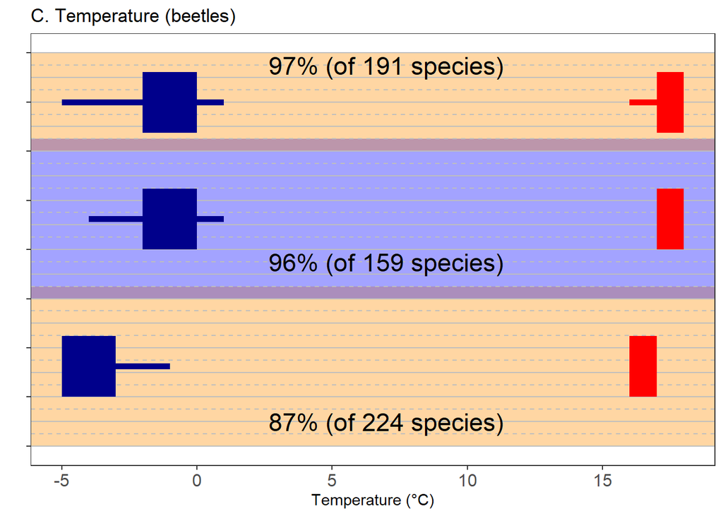

```r
MCR_bugs_SpeciesModules<- read.table("Files/MCR_results.csv",h=T, sep=",", quote="\"", fill=FALSE)


MCR_bugs_SpeciesModules$Measure <- factor(MCR_bugs_SpeciesModules$Measure,
                                          levels=c("TMin", "TMax"), ordered = T)


# crate plot:
Fig2C <- ggplot(data = MCR_bugs_SpeciesModules)+
  geom_blank(aes(x = -5)) +
  geom_blank(aes(x = 18))+
  geom_rect(mapping = aes(ymin = Oldest, ymax = Youngest, xmin = -Inf, xmax = Inf),
            data = MCR_bugs_SpeciesModules, alpha = 0.2, fill = c("darkorange","blue",
                                                                  "darkorange",
                                                                  "darkorange","blue",
                                                                  "darkorange"),inherit.aes = FALSE) +
  geom_hline(yintercept=seq(0, 16000,by=500), colour="grey", linetype="dashed")+
  geom_hline(yintercept=seq(0, 16000,by=1000), colour="grey")+
  geom_segment(aes(y = Age, yend = Age, x = Start, xend = End,color=Measure),
               size = 20, alpha = 1) +
  geom_segment(aes(y = Age, yend = Age, x = JackStart, xend = JackEnd,color=Measure),
               size = 2, alpha = 1) +
  scale_color_manual(values = c("TMin" = "darkblue","TMax" = "red"))+
  ylab("")+
  xlab("Temperature (°C)")+
  theme_bw()+
  theme(legend.position = "none")+
  ggtitle("C. Temperature (beetles)")+
  theme(strip.background = element_rect(fill="white",  linetype=NULL))+
  scale_y_reverse(breaks=seq(0,16000,  2000),labels = comma)+
  annotate("text", y=c(15000, 8500,500), x=7, col=1,
           label=c("87% (of 224 species)", "96% (of 159 species)", "97% (of 191 species)"),
           alpha = 1, size=6,angle = 0)+
  theme(legend.position = "none", panel.background = element_blank(),
        panel.grid.major.x = element_blank(),panel.grid.minor.x = element_blank(),
        axis.text.y = element_blank(),
        axis.text=element_text(size=12))
```

FIGURE 2C: Reconstruction of the ranges of mean temperature of the coldest (TMin, blue) and warmest (TMax, red) months, based on the temperature envelopes of the species occurring in the modules SM1-3. Bars show the jackknife ranges.

Figure 2D shows the changes in trait importance for the modules. Trait importance is defined as the amount of flow volume resulting from the network analysis.

First, we load the output of the trait-based network, we convert *layer_id* into *year* BP.

```r
Trait_network_module <-readInfomapTree("Files/Network_traits_states.tree", network.summary = T, replace.leaf.names = F)
names(Trait_network_module)<- c("path", "flow", "name", "state_id", "node_id", "layer_id", "lvl1", "lvl2", "lvl3", "lvl4", "lvl5")
Samples_list_module <- Trait_network_module$name[grep("COUN", Trait_network_module$name)]
Trait_module <- Trait_network_module[!Trait_network_module$name %in% Samples_list_module,]
Trait_module <-Trait_module[,c(1:10)]
# convert "layer" into "year":
Trait_module$year <- (Trait_module$layer_id*500)-250
```

We compute the relative flow of traits per module (i.e. 500-year bin).

```r
# Total flow:
TotFlow_module_lvl2 <- Trait_module %>%
  group_by(lvl2) %>%
  summarise(TotFlowMod = sum(flow))
Trait_module2_lvl2 <- merge(Trait_module, TotFlow_module_lvl2, by="lvl2")

# compute relative flow of traits per module (i.e. 500-year bin):
Trait_module3_lvl2 <- Trait_module2_lvl2 %>%
  select(lvl2 ,name,flow,TotFlowMod) %>%
  group_by(lvl2 ,name,TotFlowMod) %>%
  summarise(SumFlow = sum(flow))
Trait_module3_lvl2$RelativeFlow <- Trait_module3_lvl2$SumFlow/Trait_module3_lvl2$TotFlowMod

# compute year
Modules_year_lvl2<- Trait_module %>%
  group_by(lvl2) %>%
  summarise(Year_avg = mean(year))

Trait_module4_lvl2 <- merge(Trait_module3_lvl2, Modules_year_lvl2, by="lvl2")

# Order traits:
Modules <- read.table("Files/Modules.csv",h=T, sep=",", quote="\"", fill=FALSE)
names(Modules)[1] <- "Module"

Trait_module4_lvl3 <- merge(Trait_module4_lvl2, Modules, by.x="lvl2", by.y="Module")
Trait_module4_lvl3$name <- factor(Trait_module4_lvl3$name, levels=c("We","Aq","ISt","IRu","Op", "Me","Sa","He","Ha","Wo","ICo","IDe","Dr", "Pa","Di","Ca","Du","IDu","Mo", "St","Ge"), ordered=T)

Fig2D <- ggplot(Trait_module4_lvl3, aes(x = (RelativeFlow*100), y = (Year_avg))) +
  facet_geochem_gridh(vars(name)) +
  theme(legend.position = "none", panel.background = element_blank(),panel.grid.major.y = element_blank(),panel.grid.minor.y =    element_blank())+
  geom_hline(yintercept=seq( 0, 16000,by=500),colour="grey", linetype="dashed")+
  geom_hline(yintercept=seq( 0, 16000,by=1000),colour="grey")+
  labs(x = "Flow (%)", y = "Years BP")+
  scale_y_reverse(breaks=seq(0,16000,  2000),labels =comma)+
  geom_rect(mapping = aes(ymin = Yr_from, ymax = Yr_to , xmin = 0, xmax = (RelativeFlow *100), fill = Name),
            data = Trait_module4_lvl3 , alpha = 0.6,inherit.aes = FALSE) +
  scale_fill_manual(values=c("darkorange", "blue","darkorange", "blue","darkorange", "blue","darkorange", "blue"))+
  #geom_col_segsh(col="grey30",size=1)+
  #geom_lineh(size=1)+
  ggtitle("D. Importance of traits for modules")+
  theme_bw()+
  theme(axis.text.x = element_text(size = 7,angle =90),
        strip.background = element_rect(fill="white",  linetype=NULL),
        legend.position="none",
        axis.text.y = element_text(size = 12,angle =0))

#pdf("Figure2D_new_pdf.pdf",10,6)   #14,10
#Fig2D
#dev.off()
```

Figure 2D:

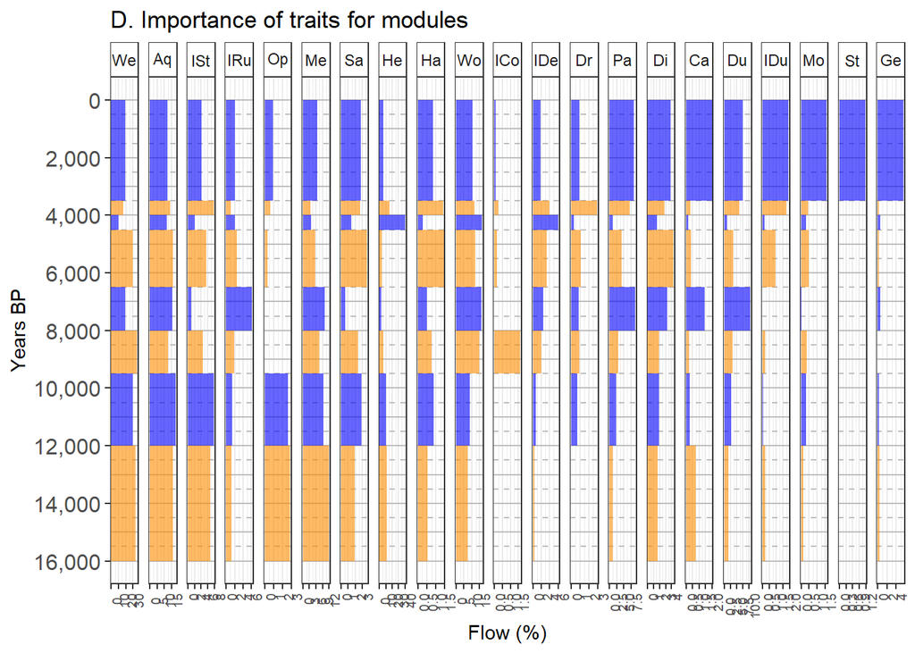

FIGURE 2D: Changes in trait importance for the modules, defined as the amount of flow volume resulting from the network analysis; the colours delineate the trait-based modules; note the different scales on the x-axes. See Appendix 1 for a description of the traits.

# 3. Indicator Value analysis

To identify the significant associations between traits and modules, we run an Indicator Value (IndVal) analysis, based on the percent flow per trait per layer.

First we create a cross table with layer (i.e. 500-year bins) as rows, traits as columns, and *RelativeFlow* as value. Then, we add the module information.

```r
# compute total flow per layer (i.e. 500-year bin):
TotFlow_layer <- Trait_module %>%
  group_by(year) %>%
  summarise(TotFlowLayer = sum(flow))
Trait_states2 <- merge(Trait_module, TotFlow_layer, by="year")

# compute relative flow of traits per layer (i.e. 500-year bin):
Trait_states3 <- Trait_states2 %>%
  group_by(lvl2 ,year,name,TotFlowLayer) %>%
  summarise(RelativeFlow = sum(flow)/TotFlowLayer)


Tr.crossT <- cast(Trait_states3,  year ~ name, value = "RelativeFlow",fill=0)
year_module <- Trait_states3[, c("year", "lvl2")]
year_module <- year_module[!duplicated(year_module),]
Tr.crossT2 <- merge(year_module, Tr.crossT, by="year")
```

We run the IndVal analysis for the groups of trait-based modules that reflect the species-based modules.

```r
# Add labels for groups of modules:
Tr.crossT2$Module_taxonomy <- ifelse(Tr.crossT2$lvl2 %in% c("2.2","2.1"), "SM1",
                                              ifelse(Tr.crossT2$lvl2%in% c("2.3","1.3", "1.2","1.5","1.4"), "SM2",
                                                     ifelse(Tr.crossT2$lvl2 %in% c("1.1"), "SM3", NA)))

# compute IndVal with 999 permutations:
set.seed(2222) # set.seed for reproducibility of permutation results
INDVAL_Groups_modules = multipatt(Tr.crossT2[,c(3:23)], Tr.crossT2$Module_taxonomy, duleg =T,control = how(nperm=999))
```

```r
summary(INDVAL_Groups_modules)
```

```
##
##  Multilevel pattern analysis
##  ---------------------------
##
##  Association function: IndVal.g
##  Significance level (alpha): 0.05
##
##  Total number of species: 21
##  Selected number of species: 12
##  Number of species associated to 1 group: 12
##  Number of species associated to 2 groups: 0
##
##  List of species associated to each combination:
##
##  Group SM1  #sps.  3
##     stat p.value
## Op 0.774   0.018 *
## Me 0.695   0.002 **
## We 0.663   0.001 ***
##
##  Group SM2  #sps.  1
##     stat p.value
## Wo 0.662   0.013 *
##
##  Group SM3  #sps.  8
##      stat p.value
## Ge  0.943   0.001 ***
## IDu 0.888   0.001 ***
## Ca  0.835   0.001 ***
## Mo  0.833   0.015 *
## Pa  0.767   0.002 **
## Du  0.737   0.003 **
## Di  0.689   0.045 *
## St  0.655   0.008 **
## ---
## Signif. codes:  0 '***' 0.001 '**' 0.01 '*' 0.05 '.' 0.1 ' ' 1
```

# 4. Supplementary Figure S3

Supplementary Figure S3 shows the temporal and latitudinal distribution of the species-based and trait-based modules, and their robustness. We first obtain the latitude of the samples from *LegendSamples*.

```r
LegendSamples_lat <- LegendSamples[,c("sample_identifier_short","latitude_dd")]
LegendSamples_lat <- LegendSamples_lat[!duplicated(LegendSamples_lat),]
```

We read the taxonomy-based network, we remove the small, non-significant modules and add the latitude information to the samples.

```r
Tax_network <-readInfomapTree("Files/Network_taxonomy_states.tree", network.summary = T, replace.leaf.names = F)
names(Tax_network)<- c("path", "flow", "name", "state_id", "node_id", "layer_id", "lvl1", "lvl2")

# remove small modules
summary(factor(Tax_network$lvl1))
summary(factor(Tax_network$lvl2))
Tax_network <- Tax_network[Tax_network$lvl1 %in% c(1:3),]

# add latitude samples:
N_strat_Lat <- merge(Tax_network[,c("name", "layer_id","lvl1","lvl2")],LegendSamples_lat, by.x="name", by.y="sample_identifier_short")
N_strat_Lat$Module <- paste("M",N_strat_Lat$lvl1, sep="_")
N_strat_Lat$Module_lvl2 <- paste("M",N_strat_Lat$lvl2, sep="_")
```

We load the results of the robustness analysis, and compute the number of simulations where Jaccard index is greater than 0.7.

```r
Robust_taxa <- read.table("Files/Robustness_taxonomy.csv",h=T, sep=",", quote="\"", fill=FALSE)

# compute number of simulations where jaccard>0.7
Robust_taxa1 <- Robust_taxa %>%
  group_by(layer_id) %>%
  summarize(jac09= length(jaccard[jaccard>0.7]))
```

We convert *layer_id* into *year* BP, and create the first panel of the plot.

```r
N_strat_Lat$year <- (N_strat_Lat$layer_id*500)-250
Robust_taxa1$year <- (Robust_taxa1$layer_id*500)-250

Sup_Fig3A_with_prob <- ggplot()+
  geom_point(data= N_strat_Lat, aes(x=year, y=latitude_dd, col=Module), size=3)+
  annotate("rect", xmin = c(9500,3500), xmax = c(10000,4000), ymin = -Inf, ymax = Inf, fill="grey50",
           alpha = .6)+
  scale_color_manual(values=alpha(c("darkorange",  "darkorange","blue"), 1)) +
  theme_bw()+
  theme(legend.position = "none", panel.background = element_blank(),panel.grid.major.y = element_blank(),panel.grid.minor.y = element_blank())+
  geom_vline(xintercept=seq( 0, 16000,by=500),colour="grey", linetype="dashed")+
  geom_vline(xintercept=seq( 0, 16000,by=1000),colour="grey")+
  scale_x_reverse(breaks=seq(0,16000,  2000),labels =comma)+
  xlab("Years BP")+
  ggtitle("A. Taxonomy")+
  annotate("text", x=c(13000, 7500,2500), y=32, col=1,label=c("SM1", "SM2", "SM3"),
           alpha = .9, size=4.5, fontface=2)+
  scale_y_continuous(
    name = "Latitude (\u00B0)", lim=c(20,85),
    sec.axis = sec_axis(~.*1.2, name="Probability (%)")) +
  geom_line(data=Robust_taxa1, aes(x=year, y=jac09/1.2))+
  geom_point(data=Robust_taxa1, aes(x=year, y=jac09/1.2), size=1)

Sup_Fig3A <- ggplot()+
  geom_point(data= N_strat_Lat, aes(x=year, y=latitude_dd, col=Module), size=3)+
  annotate("rect", xmin = c(9500,3500), xmax = c(10000,4000), ymin = -Inf, ymax = Inf, fill="grey50",
           alpha = .6)+
  scale_color_manual(values=alpha(c("darkorange",  "darkorange","blue"), 1)) +
  theme_bw()+
  theme(legend.position = "none", panel.background = element_blank(),panel.grid.major.y = element_blank(),panel.grid.minor.y = element_blank())+
  geom_vline(xintercept=seq( 0, 16000,by=500),colour="grey", linetype="dashed")+
  geom_vline(xintercept=seq( 0, 16000,by=1000),colour="grey")+
  scale_x_reverse(breaks=seq(0,16000,  2000),labels =comma)+
  xlab("Years BP")+
  ggtitle("A. Taxonomy")+
  annotate("text", x=c(13000, 7500,2500), y=45, col=1,label=c("SM1", "SM2", "SM3"),
           alpha = .9, size=4.5, fontface=2)+
  scale_y_continuous(
    name = "Latitude (\u00B0)", lim=c(40,70))
```

```r
Trait_network <-readInfomapTree("Files/Network_traits_states.tree", network.summary = T, replace.leaf.names = F)
names(Trait_network)<- c("path", "flow", "name", "state_id", "node_id", "layer_id", "lvl1", "lvl2")

SingleTrait_Lat <- merge(Trait_network[,c("name", "layer_id","lvl1","lvl2")],LegendSamples_lat, by.x="name", by.y="sample_identifier_short")
SingleTrait_Lat$Module <- paste("M",SingleTrait_Lat$lvl2, sep="_")
SingleTrait_Lat$year <- (SingleTrait_Lat$layer_id*500)-250

# robustness
Robust_traits <- read.table("Files/Robustness_traits.csv",h=T, sep=",", quote="\"", fill=FALSE)

# compute number of simulations where jaccard>0.7
Robust_traits1 <- Robust_traits %>%
  group_by(layer_id) %>%
  summarize(jac09= length(jaccard[jaccard>0.8]))
# add year
Robust_traits1$year <-  (Robust_traits1$layer_id*500)-250

#plot
Sup_Fig3B_with_prob <- ggplot()+
  geom_point(data=SingleTrait_Lat, aes(x=year, y=latitude_dd, col=Module), size=3) +
  scale_color_manual(values=alpha(c("blue","darkorange", "blue","darkorange", "blue","darkorange", "blue","darkorange"), 1)) +
  theme_bw()+
  theme(legend.position = "none", panel.background = element_blank(),panel.grid.major.y = element_blank(),panel.grid.minor.y = element_blank())+
  geom_vline(xintercept=seq( 0, 16000,by=500),colour="grey", linetype="dashed")+
  geom_vline(xintercept=seq( 0, 16000,by=1000),colour="grey")+
  scale_x_reverse(breaks=seq(0,16000,  2000),labels =comma)+
  xlab("Years BP")+
  ggtitle("B. Ecological traits")+
  annotate("text", x=c(14000,11000,9000,7500,5500,4200,3500,1500), y=c(rep(32,5),25,32,32), col=1,label=c("TM1", "TM2", "TM3","TM4", "TM5", "TM6", "TM7", "TM8"),
           alpha = 1, size=4.5, fontface=2)+
  annotate("segment", x= c(12000, 10000, 8000, 6500, 4500,4000,3500), xend = c(12000, 10000, 8000, 6500, 4500,4000,3500), y=-Inf, yend=Inf, col="grey50", size=1.2, alpha=0.6)+
  geom_line(data=Robust_traits1, aes(x=year, y=jac09/1.2))+
  geom_point(data=Robust_traits1, aes(x=year, y=jac09/1.2), size=1)+
  scale_y_continuous(
    name = "Latitude (\u00B0)",lim=c(20,85),
    sec.axis = sec_axis(~.*1.2, name="Probability (%)"))

Sup_Fig3B <- ggplot()+
  geom_point(data=SingleTrait_Lat, aes(x=year, y=latitude_dd, col=Module), size=3) +
  scale_color_manual(values=alpha(c("blue","darkorange", "blue","darkorange", "blue","darkorange", "blue","darkorange"), 1)) +
  theme_bw()+
  theme(legend.position = "none", panel.background = element_blank(),panel.grid.major.y = element_blank(),panel.grid.minor.y = element_blank())+
  geom_vline(xintercept=seq( 0, 16000,by=500),colour="grey", linetype="dashed")+
  geom_vline(xintercept=seq( 0, 16000,by=1000),colour="grey")+
  scale_x_reverse(breaks=seq(0,16000,  2000),labels =comma)+
  xlab("Years BP")+
  ggtitle("B. Ecological traits")+
  annotate("text", x=c(14000,11000,9000,7500,5500,4200,3500,1500), y=c(rep(45,5),43,45,45), col=1,label=c("TM1", "TM2", "TM3","TM4", "TM5", "TM6", "TM7", "TM8"),
           alpha = 1, size=4.5, fontface=2)+
  annotate("segment", x= c(12000, 10000, 8000, 6500, 4500,4000,3500), xend = c(12000, 10000, 8000, 6500, 4500,4000,3500), y=-Inf, yend=Inf, col="grey50", size=1.2, alpha=0.6)+
  scale_y_continuous(name = "Latitude (\u00B0)",lim=c(40,70))
```

Figure S3:

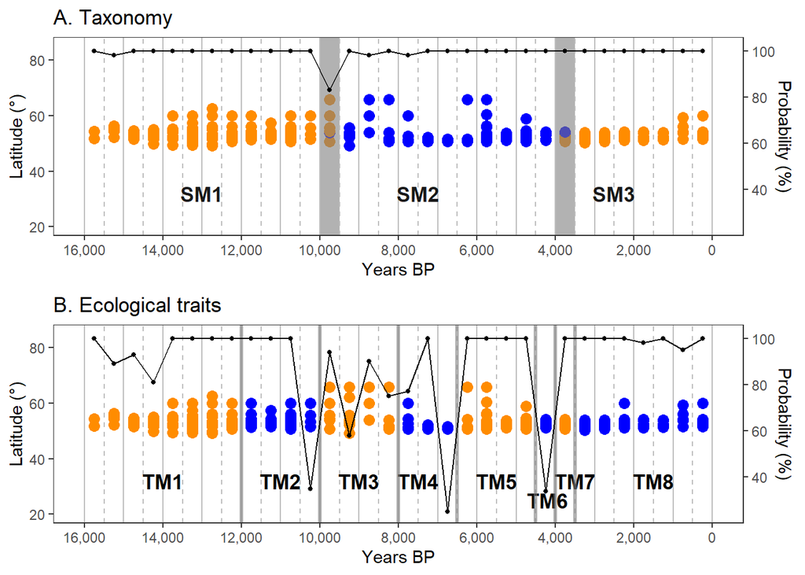

```r
#tiff("Suppl_Fig3.tif",6,6,units="in",compression="lzw",res=600)   #14,10
grid.arrange(Sup_Fig3A_with_prob, Sup_Fig3B_with_prob,heights=c(1,1),  ncol=1)
```

```r
dev.off()
```

This analysis uses the following version of R and R packages:

```
##                _
## version.string R version 4.0.3 (2020-10-10)
```

```
##        stringr          tidyr   indicspecies        permute        reshape
##        "1.4.0"        "1.1.4"       "1.7.12"        "0.9-5"        "0.8.8"
##      tidypaleo        cowplot      rworldmap             sp      gridExtra
##        "0.1.2"        "1.1.1"        "1.3-6"        "1.4-6"          "2.3"
##         scales          dplyr        ggplot2 biogeonetworks          knitr
##        "1.1.1"        "1.0.7"        "3.3.5"        "0.1.2"         "1.36"
```